# ECo 602 - Analysis of Environmental Data

## Model Diagnostics

This section will evaluate whether the five created models from the previous section fulfill the assumption of normality of the residuals.

First, we will show a graphical approach using histograms for each model’s residuals. Second, we will use the Shapiro test on each of the five models to test the null hypothesis, which is that the residuals are drawn from a normally distributed population.

### Model 1

#### Model 1 Histogram:

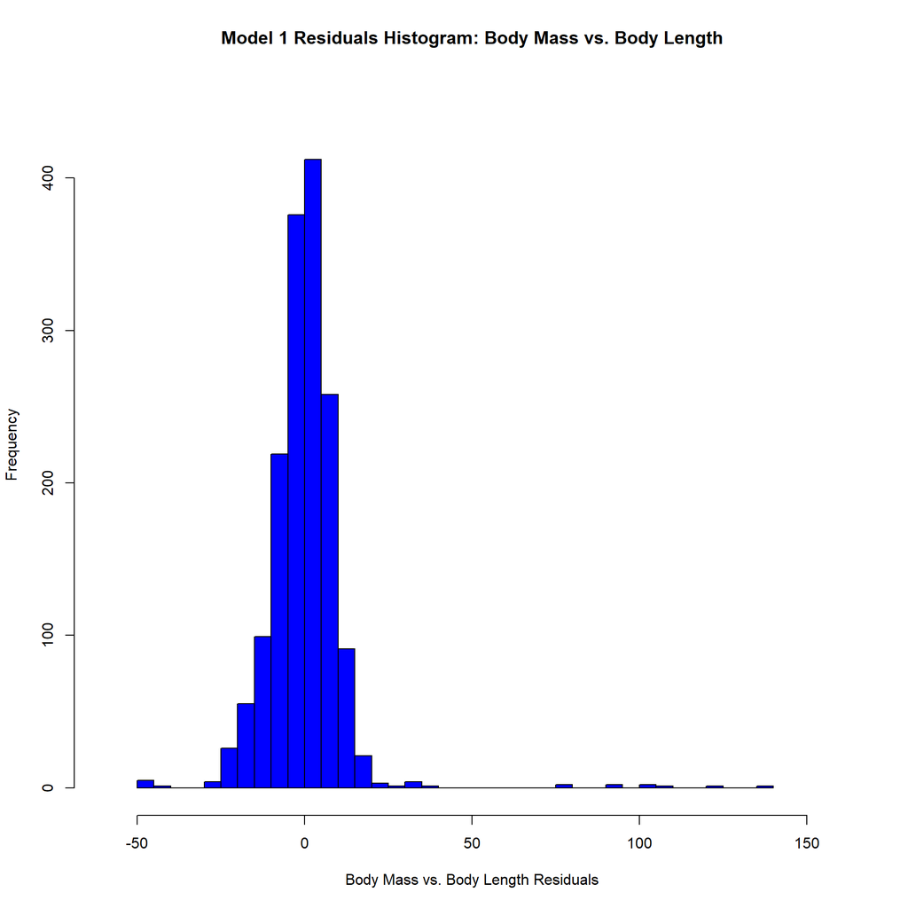

```r
fit1residual <- residuals(fit1) # Body mass vs. body length residuals.

hist(fit1residual,
     main = "Model 1 Residuals Histogram: Body Mass vs. Body Length",
     xlab = "Body Mass vs. Body Length Residuals",
     col = "blue",
     breaks = 30,
     xlim = c(-60, 160),
     ylim = c(0, 450))
```

#### Model 1 Shapiro Test:

```r
shapiro.test(fit1residual)
```

```
##
##  Shapiro-Wilk normality test
##
## data:  fit1residual
## W = 0.73462, p-value < 2.2e-16
```

### Model 2

#### Model 2 Histogram:

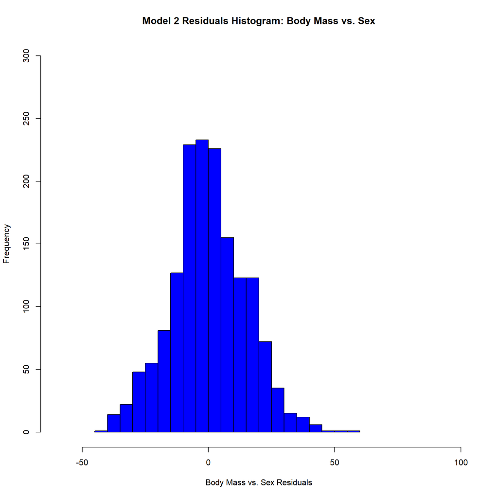

```r
fit2residual <- residuals(fit2) # Body mass vs. sex residuals.

hist(fit2residual,
     main = "Model 2 Residuals Histogram: Body Mass vs. Sex",
     xlab = "Body Mass vs. Sex Residuals",
     col = "blue",
     breaks = 30,
     xlim = c(-60, 100),
     ylim = c(0, 300))
```

#### Model 2 Shapiro Test:

```r
shapiro.test(fit2residual)
```

```
##
##  Shapiro-Wilk normality test
##
## data:  fit2residual
## W = 0.99563, p-value = 0.0001541
```

### Model 3

#### Model 3 Histogram:

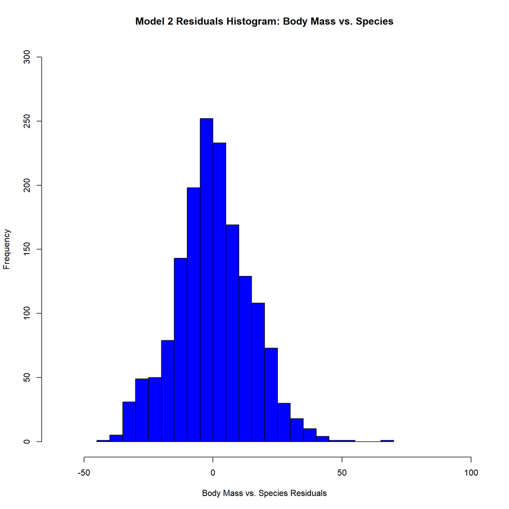

```r
fit3residual <- residuals(fit3) # Body mass vs. species residuals.

hist(fit3residual,
     main = "Model 2 Residuals Histogram: Body Mass vs. Species",
     xlab = "Body Mass vs. Species Residuals",
     col = "blue",
     breaks = 30,
     xlim = c(-60, 100),
     ylim = c(0, 300))
```

#### Model 3 Shapiro Test:

```r
shapiro.test(fit3residual)
```

```
##
##  Shapiro-Wilk normality test
##
## data:  fit3residual
## W = 0.99535, p-value = 8.103e-05
```

### Model 4

#### Model 4 Histogram:

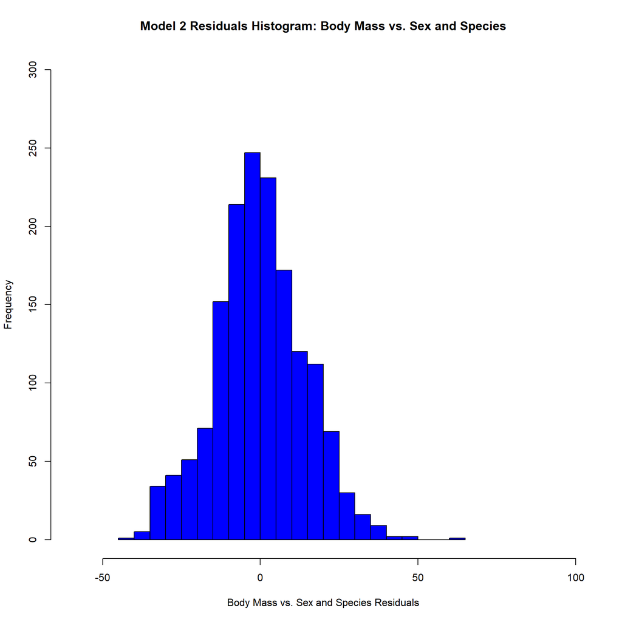

```r
fit4residual <- residuals(fit4) # Body mass vs. sex + species residuals.

hist(fit4residual,
     main = "Model 2 Residuals Histogram: Body Mass vs. Sex and Species",
     xlab = "Body Mass vs. Sex and Species Residuals",
     col = "blue",
     breaks = 30,
     xlim = c(-60, 100),
     ylim = c(0, 300))
```

#### Model 4 Shapiro Test:

```r
shapiro.test(fit4residual)
```

```
##
##  Shapiro-Wilk normality test
##
## data:  fit4residual
## W = 0.99525, p-value = 6.805e-05
```

### Model 5

#### Model 5 Histogram:

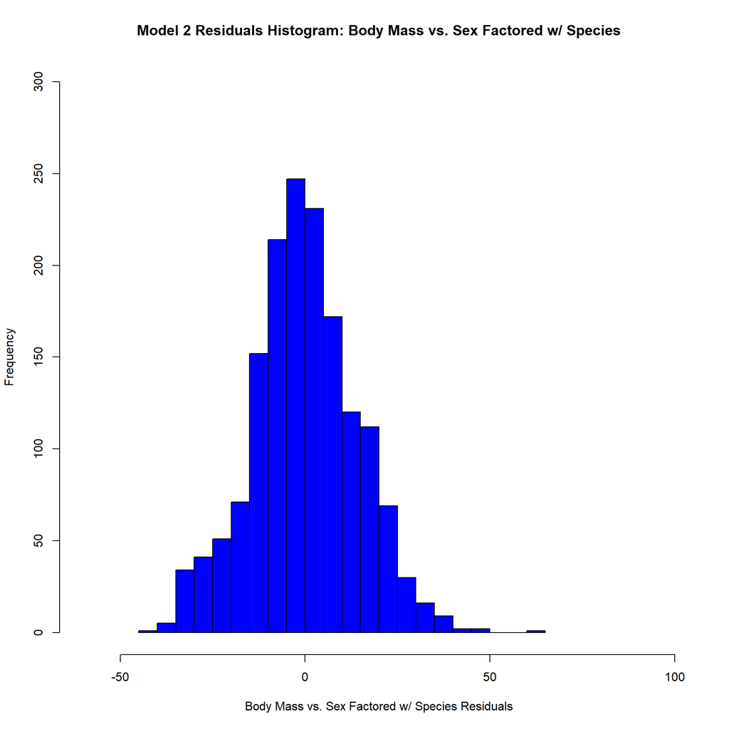

```r
fit5residual <- residuals(fit5) # Body mass vs. sex * species residuals.

hist(fit5residual,
     main = "Model 2 Residuals Histogram: Body Mass vs. Sex Factored w/ Species",
     xlab = "Body Mass vs. Sex Factored w/ Species Residuals",
     col = "blue",
     breaks = 30,
     xlim = c(-60, 100),
     ylim = c(0, 300))
```

#### Model 5 Shapiro Test:

```r
shapiro.test(fit5residual)
```

```
##
##  Shapiro-Wilk normality test
##
## data:  fit5residual
## W = 0.99526, p-value = 6.816e-05
```

### Questions

#### Question 1:

**What do you conclude about residual normality based on the numerical and graphical diagnostics?**

#### Question 2:

**Are violations of the normality assumption equally severe for all the models?**

## Model Interpretation

### Body Length

#### Coefficient Table:

```r
knitr::kable(coef(summary(fit1)))
```

|  | Estimate | Std. Error | t value | Pr(>\|t\|) |
| --- | --- | --- | --- | --- |
| (Intercept) | 76.1246565 | 0.9158120 | 83.12258 | 0 |
| body_mass | 0.8754988 | 0.0196905 | 44.46298 | 0 |

#### Scatterplot of Delomys *body mass* and *body length*:

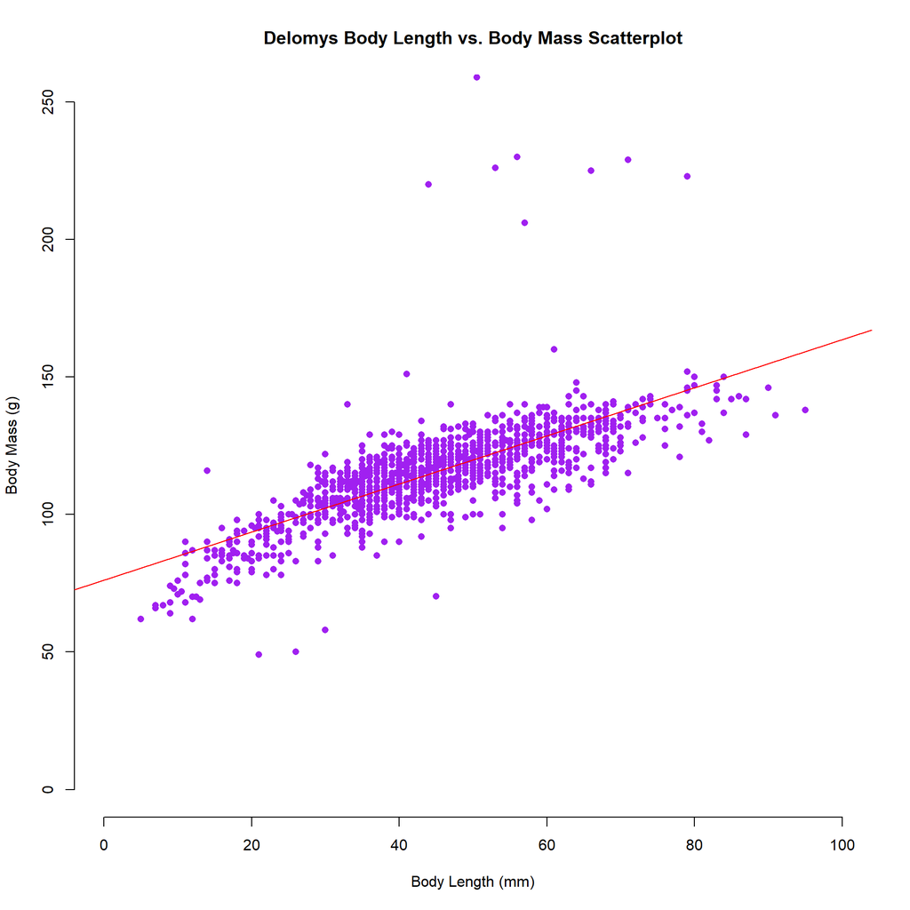

```r
plot(
  body_length ~ body_mass,
  data = delomys,
  main = "Delomys Body Length vs. Body Mass Scatterplot",
  xlab = "Body Length (mm)",
  ylab = "Body Mass (g)",
  col = "purple",
  pch = 16,
  frame = FALSE,
  xlim = c(0,100),
  ylim = c(0,250))

abline(lm(body_length~body_mass, data=delomys), col="red") #Regression line
```

#### Questions:

**1) What is the magnitude of the mass/length relationship?**

**2) What is the expected body length of an an animal that weighs 100g?**

**3) What is the expected body length of an animal that weighs 0g?**

### Body Mass: Model Coefficients

#### Coefficient Tables:

```r
knitr::kable(coef(summary(fit2)))
```

|  | Estimate | Std. Error | t value | Pr(>\|t\|) |
| --- | --- | --- | --- | --- |
| (Intercept) | 42.711465 | 0.5288929 | 80.756355 | 0.0000000 |
| sexmale | 2.784133 | 0.7456117 | 3.734024 | 0.0001951 |

```r
knitr::kable(coef(summary(fit3)))
```

|  | Estimate | Std. Error | t value | Pr(>\|t\|) |
| --- | --- | --- | --- | --- |
| (Intercept) | 46.752427 | 0.4499933 | 103.89582 | 0 |
| binomialDelomys sublineatus | -7.683058 | 0.7604562 | -10.10322 | 0 |

#### Questions:

**1) What is the base level for sex?**

The base intercept coefficient is 42.71.

**2) What is the base level for binomial?**

The base intercept coefficient is 46.75.

**3) Which sex is heavier?**

Male sex.

This is represented in the coefficient table in that the base intercept implies the lower weight sex of Delomys, which in this case is female. The table tells us that for analyzing males we would be adding the *sexmale* coefficient of 2.78 to our calculations, meaning that males weigh more.

**4) Which species is heavier?**

Delomys dorsalis.

With similar logic to the previous question, this is represented in the coefficient table in that the base intercept implies the higher weight species as the baseline. The negative coefficient for *Delomys sublineatus* means that we would be subtracting 7.68 grams from the base coefficient when analyzing this species, meaning that they weigh less.

### Body Mass: ANOVA

#### Coefficient Tables:

```r
knitr::kable(coef(summary(fit4)))
```

|  | Estimate | Std. Error | t value | Pr(>\|t\|) |
| --- | --- | --- | --- | --- |
| (Intercept) | 45.070355 | 0.5556429 | 81.113891 | 0e+00 |
| sexmale | 3.795395 | 0.7259609 | 5.228099 | 2e-07 |
| binomialDelomys sublineatus | -8.193492 | 0.7609985 | -10.766764 | 0e+00 |

```r
knitr::kable(coef(summary(fit5)))
```

|  | Estimate | Std. Error | t value | Pr(>\|t\|) |
| --- | --- | --- | --- | --- |
| (Intercept) | 45.0554562 | 0.6052973 | 74.4352459 | 0.0000000 |
| sexmale | 3.8280908 | 0.8966667 | 4.2692460 | 0.0000208 |
| binomialDelomys sublineatus | -8.1417394 | 1.1281046 | -7.2171847 | 0.0000000 |
| sexmale:binomialDelomys sublineatus | -0.0950187 | 1.5285856 | -0.0621612 | 0.9504424 |

#### Questions:

**1) Are sex and species significant predictors for body mass?**

Yes. The p value is less than 0.05 or 5%.

**2) Is there a significant interaction?**

No.

**3) Does the significance (as measured by p-value) of either of the main effects (sex and species) differ much between the single-predictor models, the additive model, and the interactive model?**

No.

## Model Comparison

```r
AIC(fit1)
```

```
## [1] 12291.67
```

```r
AIC(fit2)
```

```
## [1] 13006.8
```

```r
AIC(fit3)
```

```
## [1] 12966.36
```

```r
AIC(fit4)
```

```
## [1] 12896.73
```

```r
AIC(fit5)
```

```
## [1] 12898.72
```

#### Questions:

**1) Which two models have the lowest AIC?**

Model 4 (fit 4) and Model 5 (fit 5). Model 1 (fit 1) is factoring body length, thus its AIC value is misleading.

**2) Which of the two models with lowest AIC scores would you select? Explain your decision based on model fit and the complexity/understanding trade-off.**

Model 4 (fit 4) because it the lowest of the two AIC’s. However, since the values differ almost insignificantly, both would be justified to select in this case.